# Methods for Data Science M345 A50 Coursework 2 - Networks

The following is the result of applying eigenvector centrality, which seeks to assign centralities such that a node is important if it is connected to other important nodes (this is done recursively).

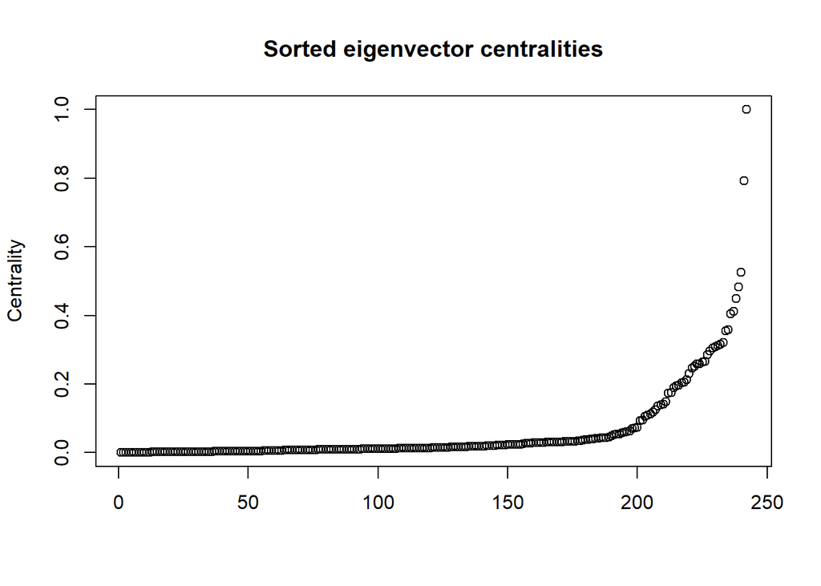

As one might expect, this measure places great emphasis on a small number of nodes all connected to each other, whilst most nodes are left outside of this bubble.

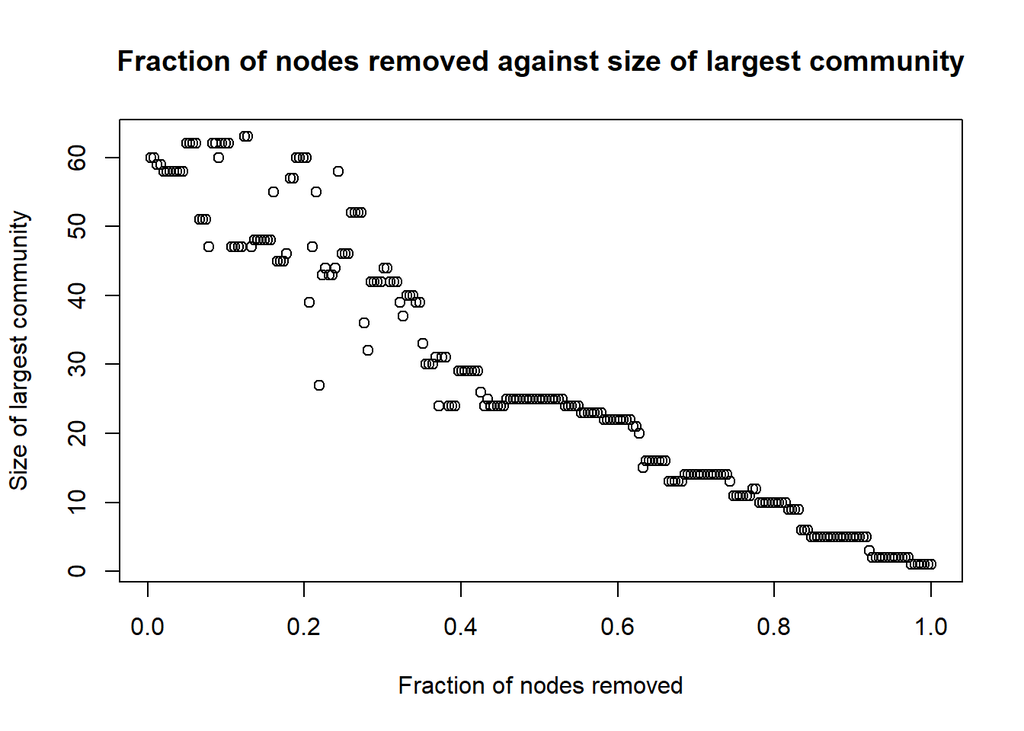

The largest community size is very variable at first, perhaps because removing one of these crucial nodes in the ‘important bubble’ changes the structure of the network significantly.

This final measure is page-rank centrality, the algorithm used by Google to place its search results in order. This is similar to eigenvector centrality, but it compensates both for high or low centralities propagating to other nodes (i.e. hopefully preventing a ‘bubble’ as seen above).

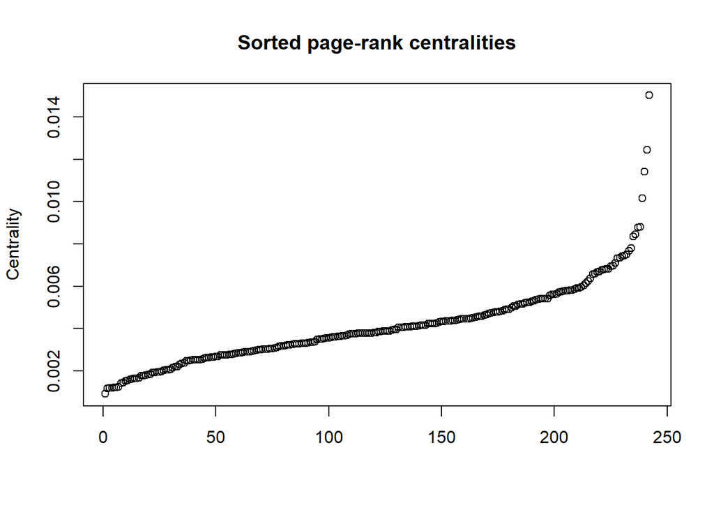

There is still a focus on a small number of nodes, but the other nodes are not so completely ignored as they were for eigenvector centrality.

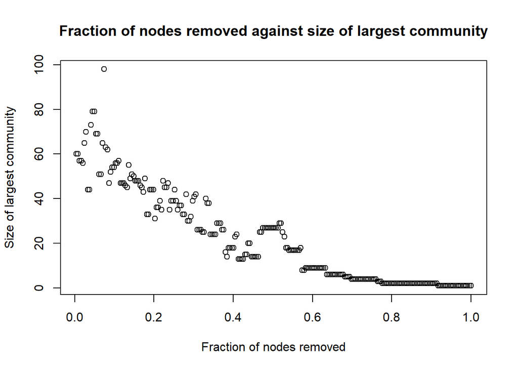

We can plot two measures of centrality against each other node-by-node, and see how strongly they correlate. For instance, here is a comparison of degree centrality and page-rank centrality:

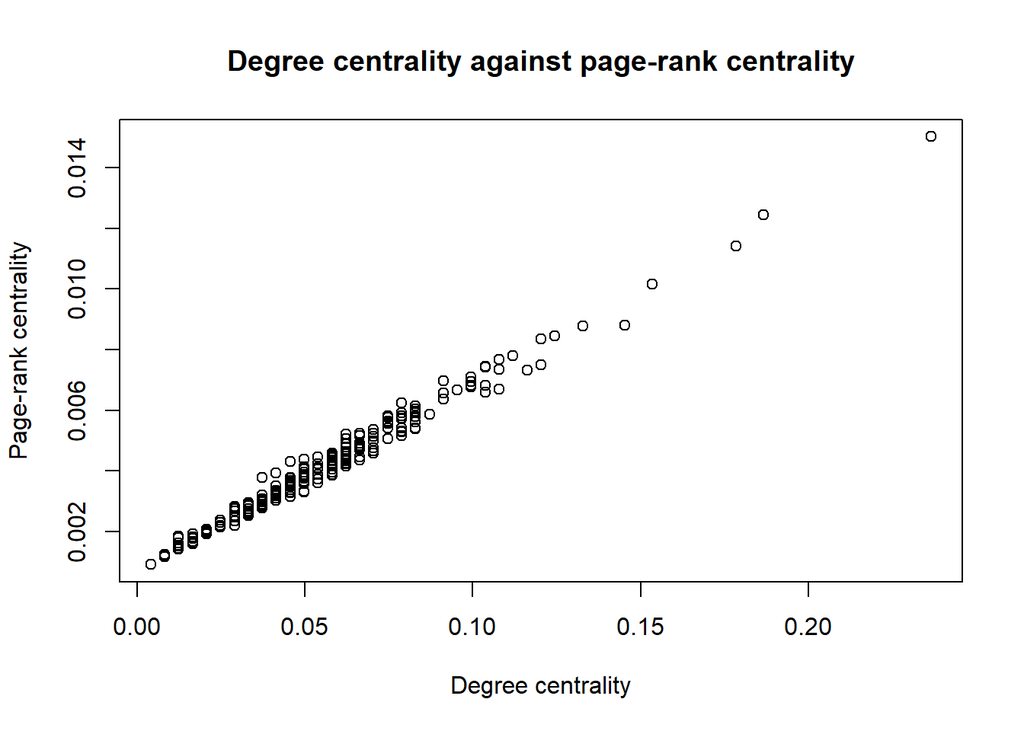

The clear linear relationship shows that the overall outcome of these two approaches is quite similar, perhaps because by nature nodes with high degree will tend to have important neighbours. As a contrast, here is a comparison of degree and betweenness centrality:

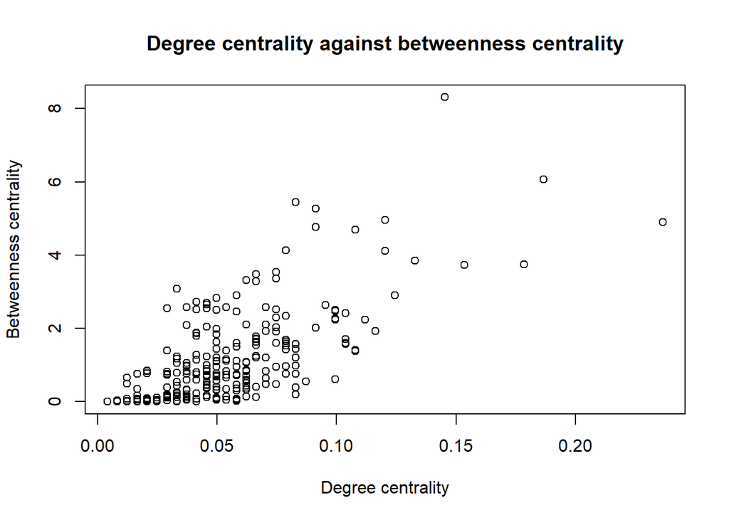